```python
# Author: Ahbaid Gaffoor
# Date: Tuesday 25th April 2017
```

# An Introduction to NumPy

## **Overview - Data Types:**

- More precise than python
- Integer: numpy.int8, numoy.int16, numpy.int32, numpy.int64
- Unsigned Integer: numpy.uint8, etc.
- Float: numpy.float32, numpy.float64, numpy.float128
- Complex: numpy.complex64, etc.
- Other Types:
  - Boolean
  - String
  - Unicode string: need to spec length in advance
  - numpy.void : put otgether composite types made of different pieces
  - numpy.object : refers to any type of python object

# Arrays

## **Creating Arrays:**

1. From a list, empty, zero, random and linearly spaced.
2. Interrogating the dtype and shape of arrays.
3. Composing arrays.
4. Loading and saving arrays

```python
# Import numpy and matplot.pyplot for plotting
```

```python
import numpy as np
import matplotlib.pyplot as pp
```

### Creation and Interrogation of Numpy Arrays

```python
# Create a numpy array, with the default data type of numpy.int64
a = np.array([1,2,3,4,5])
```

```python
a
```

```
array([1, 2, 3, 4, 5])
```

```python
a.dtype
```

```
dtype('int64')
```

```python
# Now create an array with the datatype specified as numpy.float64
a = np.array([1,2,3,4,5], dtype=np.float64)
a.dtype
```

```
dtype('float64')
```

```python
# Every array has standard attributes
a.ndim, a.shape, a.size
```

```
(1, (5,), 5)
```

```python
# Two dimensional example
b = np.array([[1,2,3,4,5],[6,7,8,9,10]], dtype=np.float64)
b
```

```
array([[  1.,   2.,   3.,   4.,   5.],
       [  6.,   7.,   8.,   9.,  10.]])
```

```python
b.dtype
```

```
dtype('float64')
```

```python
b.ndim, b.shape, b.size
```

```
(2, (2, 5), 10)
```

```python
# Declaring a 3x3 array with zeros, using shorthand 'd' for numpy.float64 type
np.zeros((3,3),'d')
```

```
array([[ 0.,  0.,  0.],
       [ 0.,  0.,  0.],
       [ 0.,  0.,  0.]])
```

```python
# Declare an empty array, will reuse memory regions as they are, so values may be non-sensical.
np.empty((4,4),'d')
```

```
array([[ 0.,  0.,  0.,  0.],
       [ 0.,  0.,  0.,  0.],
       [ 0.,  0.,  0.,  0.],
       [ 0.,  0.,  0.,  0.]])
```

```python
# Creating a regularly space array, 0 to 10 with 5 values regularly spaced
np.linspace(0,10,5)
```

```
array([  0. ,   2.5,   5. ,   7.5,  10. ])
```

```python
# Create an array, but in this case specify the step between values
# Note that arange has the same behavior like python's range
np.arange(0,10,2)
```

```
array([0, 2, 4, 6, 8])
```

```python
# a 2x4 array of random values
np.random.standard_normal((2,4))
```

```
array([[-0.66418637,  0.78067152,  0.02887106, -1.19199483],
       [-0.42949185, -0.34250401,  0.33504143, -0.6084476 ]])
```

### Composing Numpy Arrays

```python
# Composite array made from two arrays (vertically) - 4x3
a=np.random.standard_normal((2,3))
b=np.random.standard_normal((2,3))
np.vstack([a,b])
```

```
array([[-1.47661899, -1.75523127, -0.34256561],
       [ 1.52538203, -0.46950352, -0.40756341],
       [-0.98085455,  0.35715409,  1.45264942],
       [-1.31523791,  1.67882215, -0.60904008]])
```

```python
# can also stack horizontally -> 2x6
np.hstack([a,b])
```

```
array([[-1.47661899, -1.75523127, -0.34256561, -0.98085455,  0.35715409,
         1.45264942],
       [ 1.52538203, -0.46950352, -0.40756341, -1.31523791,  1.67882215,
        -0.60904008]])
```

```python
# can also transpose arrays, convert 2x3 to 3x2 array
a.transpose()
```

```
array([[-1.47661899,  1.52538203],
       [-1.75523127, -0.46950352],
       [-0.34256561, -0.40756341]])
```

### Saving and Loading Numpy Arrays

```python
# save an array to disk
np.save('example.npy',a)
```

```python
# load the array from disk
c=np.load('example.npy')
```

```python
a, c
```

```
(array([[-1.47661899, -1.75523127, -0.34256561],
        [ 1.52538203, -0.46950352, -0.40756341]]),
 array([[-1.47661899, -1.75523127, -0.34256561],
        [ 1.52538203, -0.46950352, -0.40756341]]))
```

## **Math with Arrays**

1. Applying mathematical operations to and between arrays.
2. Plotting one-dimensional arrays with matplotlib.
3. Performing linear-algebra computations with arrays.

```python
import numpy as np
import matplotlib.pyplot as pp
```

```python
# Instruct pyplot to keep plots inline with the notebooks
%matplotlib inline
```

### Applying Mathematical Operations to Numpy Arrays

```python
# Declare a linearly space 1x40 array with values equispaced from 0 to 10.
x = np.linspace(0,10,40)
x
```

```
array([  0.        ,   0.25641026,   0.51282051,   0.76923077,
         1.02564103,   1.28205128,   1.53846154,   1.79487179,
         2.05128205,   2.30769231,   2.56410256,   2.82051282,
         3.07692308,   3.33333333,   3.58974359,   3.84615385,
         4.1025641 ,   4.35897436,   4.61538462,   4.87179487,
         5.12820513,   5.38461538,   5.64102564,   5.8974359 ,
         6.15384615,   6.41025641,   6.66666667,   6.92307692,
         7.17948718,   7.43589744,   7.69230769,   7.94871795,
         8.20512821,   8.46153846,   8.71794872,   8.97435897,
         9.23076923,   9.48717949,   9.74358974,  10.        ])
```

```python
# Apply a sin fucntion to the values of x
sinx = np.sin(x)
sinx
```

```
array([ 0.        ,  0.25360981,  0.49063689,  0.69558279,  0.85504677,
        0.95860198,  0.99947728,  0.97499996,  0.88677052,  0.740558  ,
        0.54592277,  0.31559139,  0.06462451, -0.19056796, -0.43329981,
       -0.64769957, -0.81974833, -0.93819637, -0.99529876, -0.98732176,
       -0.91478695, -0.78243716, -0.59892631, -0.37625358, -0.12897884,
        0.12672941,  0.37415123,  0.5971085 ,  0.78102277,  0.91386845,
        0.98695921,  0.99551587,  0.93897894,  0.82104518,  0.64942592,
        0.43534277,  0.19279396, -0.06236104, -0.31343844, -0.54402111])
```

### Plotting one-dimensional arrays with matplotlib.

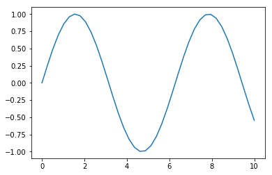

```python
pp.plot(x,sinx)
```

```python
# obtain cosine values as well for plotting
cosx = np.cos(x)
```

```python
cosx
```

```
array([ 1.        ,  0.9673066 ,  0.87136413,  0.71844595,  0.51855089,
        0.28474945,  0.03232915, -0.22220504, -0.46220996, -0.67199245,
       -0.8378355 , -0.94889519, -0.99790965, -0.981674  , -0.90124984,
       -0.76189584, -0.57272391, -0.3461034 , -0.0968523 ,  0.15873166,
        0.40393667,  0.62272955,  0.80080415,  0.92651672,  0.99164735,
        0.99193733,  0.9273677 ,  0.80216048,  0.62450255,  0.40601041,
        0.16097054, -0.09459467, -0.34397464, -0.57086321, -0.76042487,
       -0.90026478, -0.98123926, -0.99805366, -0.94960852, -0.83907153])
```

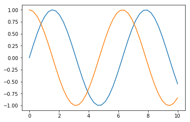

```python
# now plot both sinx and cosx
pp.plot(x,sinx)
pp.plot(x,cosx)
```

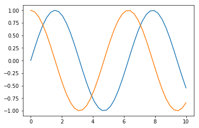

```python
# Can play with line symbols (and many more options in documentation)
pp.plot(x,sinx)
pp.plot(x,cosx)
```

```python
# Create two new arrays from sinx and cosx arrays
y = sinx * cosx
z = cosx**2 - sinx**2
y,z
```

```
(array([ 0.        ,  0.24531844,  0.42752338,  0.49973864,  0.44338526,
         0.27296138,  0.03231225, -0.2166499 , -0.40987416, -0.49764938,
        -0.45739348, -0.29946315, -0.06448942,  0.18707562,  0.39051138,
         0.49347961,  0.46948947,  0.32471296,  0.09639698, -0.15671922,
        -0.36951599, -0.48724674, -0.47962267, -0.34860524, -0.12790153,
         0.12570763,  0.34697577,  0.47897684,  0.48775071,  0.3710401 ,
         0.15887136, -0.09417049, -0.32298494, -0.46870449, -0.49383962,
        -0.39192376, -0.189177  ,  0.06223966,  0.29764381,  0.45647263]),
 array([ 1.        ,  0.87136413,  0.51855089,  0.03232915, -0.46220996,
        -0.8378355 , -0.99790965, -0.90124984, -0.57272391, -0.0968523 ,
         0.40393667,  0.80080415,  0.99164735,  0.9273677 ,  0.62450255,
         0.16097054, -0.34397464, -0.76042487, -0.98123926, -0.94960852,
        -0.67367034, -0.22441581,  0.28257456,  0.71686648,  0.96672892,
         0.96787931,  0.72002171,  0.28692287, -0.21999312, -0.6703111 ,
        -0.94817697, -0.9821037 , -0.76336289, -0.34823039,  0.15649196,
         0.62095334,  0.92566098,  0.9922222 ,  0.80351269,  0.40808206]))
```

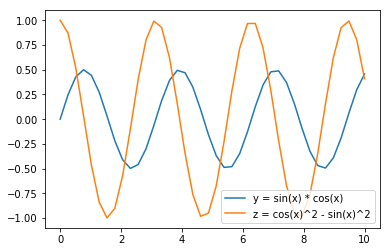

```python
# Plot the two new arrays y & z
pp.plot(x,y)
pp.plot(x,z)

# Add legends
pp.legend(['y = sin(x) * cos(x)' , 'z = cos(x)^2 - sin(x)^2'])
```

### Performing linear-algebra Computations With Numpy Arrays.

```python
# Mathematical operations in linear algebra can be applied using "dot" function, treats the arrays as vectors
np.dot(sinx,cosx)
```

```
0.79265269738691602
```

```python
# Combination of elements from the two vectors sinx and cosx, the result is a matrix
# np.outer computes matrix product
mat_outer = np.outer(sinx,cosx)
```

```python
sinx, cosx, mat_outer
```

```
(array([ 0.        ,  0.25360981,  0.49063689,  0.69558279,  0.85504677,
         0.95860198,  0.99947728,  0.97499996,  0.88677052,  0.740558  ,
         0.54592277,  0.31559139,  0.06462451, -0.19056796, -0.43329981,
        -0.64769957, -0.81974833, -0.93819637, -0.99529876, -0.98732176,
        -0.91478695, -0.78243716, -0.59892631, -0.37625358, -0.12897884,
         0.12672941,  0.37415123,  0.5971085 ,  0.78102277,  0.91386845,
         0.98695921,  0.99551587,  0.93897894,  0.82104518,  0.64942592,
         0.43534277,  0.19279396, -0.06236104, -0.31343844, -0.54402111]),
 array([ 1.        ,  0.9673066 ,  0.87136413,  0.71844595,  0.51855089,
         0.28474945,  0.03232915, -0.22220504, -0.46220996, -0.67199245,
        -0.8378355 , -0.94889519, -0.99790965, -0.981674  , -0.90124984,
        -0.76189584, -0.57272391, -0.3461034 , -0.0968523 ,  0.15873166,
         0.40393667,  0.62272955,  0.80080415,  0.92651672,  0.99164735,
         0.99193733,  0.9273677 ,  0.80216048,  0.62450255,  0.40601041,
         0.16097054, -0.09459467, -0.34397464, -0.57086321, -0.76042487,
        -0.90026478, -0.98123926, -0.99805366, -0.94960852, -0.83907153]),
 array([[ 0.        ,  0.        ,  0.        , ..., -0.        ,
         -0.        , -0.        ],
        [ 0.25360981,  0.24531844,  0.22098649, ..., -0.2531162 ,
         -0.24083004, -0.21279677],
        [ 0.49063689,  0.4745963 ,  0.42752338, ..., -0.48968194,
         -0.46591297, -0.41167944],
        ...,
        [-0.06236104, -0.06032224, -0.05433917, ...,  0.06223966,
          0.05921857,  0.05232537],
        [-0.31343844, -0.30319107, -0.27311901, ...,  0.31282838,
          0.29764381,  0.26299727],
        [-0.54402111, -0.52623521, -0.47404048, ...,  0.54296226,
          0.51660708,  0.45647263]]))
```

```python
# Numpy tries to be helpful and guess intent.
v = np.linspace(0,10,5)
v
```

```
array([  0. ,   2.5,   5. ,   7.5,  10. ])
```

```python
# Add 1 to the vector v, the number is added to each element (broadcasting)
v+1
```

```
array([  1. ,   3.5,   6. ,   8.5,  11. ])
```

```python
# Add a 1d array to a 2d array, results in a 2d arrays where the 1d array has been added to each row
vv=np.outer(v,v)
vv
```

```
array([[   0.  ,    0.  ,    0.  ,    0.  ,    0.  ],
       [   0.  ,    6.25,   12.5 ,   18.75,   25.  ],
       [   0.  ,   12.5 ,   25.  ,   37.5 ,   50.  ],
       [   0.  ,   18.75,   37.5 ,   56.25,   75.  ],
       [   0.  ,   25.  ,   50.  ,   75.  ,  100.  ]])
```

```python
vv+v
```

```
array([[   0.  ,    2.5 ,    5.  ,    7.5 ,   10.  ],
       [   0.  ,    8.75,   17.5 ,   26.25,   35.  ],
       [   0.  ,   15.  ,   30.  ,   45.  ,   60.  ],
       [   0.  ,   21.25,   42.5 ,   63.75,   85.  ],
       [   0.  ,   27.5 ,   55.  ,   82.5 ,  110.  ]])
```

```python
# Instead add to each column, by adding a new axis to v, then adding it to vv (the 2d matrix)
v[:,np.newaxis]
```

```
array([[  0. ],
       [  2.5],
       [  5. ],
       [  7.5],
       [ 10. ]])
```

```python
vv
```

```
array([[   0.  ,    0.  ,    0.  ,    0.  ,    0.  ],
       [   0.  ,    6.25,   12.5 ,   18.75,   25.  ],
       [   0.  ,   12.5 ,   25.  ,   37.5 ,   50.  ],
       [   0.  ,   18.75,   37.5 ,   56.25,   75.  ],
       [   0.  ,   25.  ,   50.  ,   75.  ,  100.  ]])
```

```python
vv + v[:,np.newaxis]
```

```
array([[   0.  ,    0.  ,    0.  ,    0.  ,    0.  ],
       [   2.5 ,    8.75,   15.  ,   21.25,   27.5 ],
       [   5.  ,   17.5 ,   30.  ,   42.5 ,   55.  ],
       [   7.5 ,   26.25,   45.  ,   63.75,   82.5 ],
       [  10.  ,   35.  ,   60.  ,   85.  ,  110.  ]])
```

# Indexing and Slicing

1. Indexing array elements
2. Slicing arrays
3. Advanced Indexing
4. NumPy vs Python-list indexing and slicing

## Indexing Array Elements

```python
import numpy as np
```

```python
v=np.linspace(0,10,5)
v
```

```
array([  0. ,   2.5,   5. ,   7.5,  10. ])
```

```python
# Traditional python indexing works
v[0]
```

```
0.0
```

```python
v[1]
```

```
2.5
```

```python
# Last element
v[-1]
```

```
10.0
```

```python
# Out of bounds
v[5]
```

```
---------------------------------------------------------------------------
IndexError                                Traceback (most recent call last)
<ipython-input-103-5db8a26c34df> in <module>()
----> 1 v[5]

IndexError: index 5 is out of bounds for axis 0 with size 5
```

```python
# Declare a numpy 5x4 array of random numbers
vv = np.random.random((5,4))
vv
```

```
array([[ 0.86797053,  0.60841306,  0.63045687,  0.28354206],
       [ 0.53832193,  0.31158791,  0.44619371,  0.26639479],
       [ 0.11921119,  0.96151355,  0.99737231,  0.27899244],
       [ 0.76348028,  0.12964753,  0.47783888,  0.95445537],
       [ 0.19970306,  0.12609192,  0.35298197,  0.96272313]])
```

```python
# Index row, column
vv[0,0], vv[4,3]
```

```
(0.86797053129298785, 0.96272313296229239)
```

```python
# Python closest equivalent does not provide the easy syntax for indexing
n = [[1,2,3],[4,5,6],[7,8,9]]
n[0], n[1], n[2]
```

```
([1, 2, 3], [4, 5, 6], [7, 8, 9])
```

```python
n
```

```
[[1, 2, 3], [4, 5, 6], [7, 8, 9]]
```

```python
# Fails for traditional python list of lists array
n[0,0]
```

```
---------------------------------------------------------------------------
TypeError                                 Traceback (most recent call last)
<ipython-input-111-e34b3ab60b8f> in <module>()
----> 1 n[0,0]

TypeError: list indices must be integers or slices, not tuple
```

```python
# Correct indexing syntax for traditional python list of lists array
n[0][0]
```

```
1
```

## Slicing Array Elements

```python
v
```

```
array([  0. ,   2.5,   5. ,   7.5,  10. ])
```

```python
vv
```

```
array([[ 0.86797053,  0.60841306,  0.63045687,  0.28354206],
       [ 0.53832193,  0.31158791,  0.44619371,  0.26639479],
       [ 0.11921119,  0.96151355,  0.99737231,  0.27899244],
       [ 0.76348028,  0.12964753,  0.47783888,  0.95445537],
       [ 0.19970306,  0.12609192,  0.35298197,  0.96272313]])
```

```python
# Traditional 1d slicing works as expected, get elements 2 & 3
v[2:4]
```

```
array([ 5. ,  7.5])
```

```python
# Select rows 2 to 4 (python range syntax)
vv[2:5]
```

```
array([[ 0.11921119,  0.96151355,  0.99737231,  0.27899244],
       [ 0.76348028,  0.12964753,  0.47783888,  0.95445537],
       [ 0.19970306,  0.12609192,  0.35298197,  0.96272313]])
```

```python
# Then select the second or column 1
vv[2:5,1]
```

```
array([ 0.96151355,  0.12964753,  0.12609192])
```

```python
# Use a slice of size 1 on the 2nd dimension instead, same data but now a vertical matrix
vv[2:5,1:2]
```

```
array([[ 0.96151355],
       [ 0.12964753],
       [ 0.12609192]])
```

```python
# Traditional slicing tricks work
# Row 2 onwards, all values up to last value of each row
vv[2:-1]
```

```
array([[ 0.11921119,  0.96151355,  0.99737231,  0.27899244],
       [ 0.76348028,  0.12964753,  0.47783888,  0.95445537]])
```

```python
# Row 2 onwards, all values up to last value of each row, last value only
vv[2:-1,-1]
```

```
array([ 0.27899244,  0.95445537])
```

```python
# All elements on both dimensions, slice step by 2
vv[:,::2]
```

```
array([[ 0.86797053,  0.63045687],
       [ 0.53832193,  0.44619371],
       [ 0.11921119,  0.99737231],
       [ 0.76348028,  0.47783888],
       [ 0.19970306,  0.35298197]])
```

```python
# Slices are views into the same shared memory space.
# Changing view values change the original collection numpy array elements
v
```

```
array([  0. ,   2.5,   5. ,   7.5,  10. ])
```

```python
v2=v[2:4]
v2
```

```
array([ 5. ,  7.5])
```

```python
v2[0]=0
v2
```

```
array([ 0. ,  7.5])
```

```python
v
```

```
array([  0. ,   2.5,   0. ,   7.5,  10. ])
```

```python
# Copies need to be explicitly stated in NumPy
v3=v[2:4].copy()
v3
```

```
array([ 0. ,  7.5])
```

```python
v
```

```
array([  0. ,   2.5,   0. ,   7.5,  10. ])
```

```python
v3[0]=99
v3
```

```
array([ 99. ,   7.5])
```

```python
v
```

```
array([  0. ,   2.5,   0. ,   7.5,  10. ])
```

## Advanced Indexing

```python
# Method 1: List of indices
v
```

```
array([  0. ,   2.5,   0. ,   7.5,  10. ])
```

```python
v[[1,2,3]]
```

```
array([ 2.5,  0. ,  7.5])
```

```python
# Method 2: Array of boolean values true or false to choose elements
v > 0
```

```
array([False,  True, False,  True,  True], dtype=bool)
```

```python
# Generate a boolean array for values of v greater than zero
bool_index = v > 0
bool_index
```

```
array([False,  True, False,  True,  True], dtype=bool)
```

```python
# Use the boolean array to display the values
v[bool_index]
```

```
array([  2.5,   7.5,  10. ])
```

## Assignment based on filter match

```python
vv
```

```
array([[ 0.86797053,  0.60841306,  0.63045687,  0.28354206],
       [ 0.53832193,  0.31158791,  0.44619371,  0.26639479],
       [ 0.11921119,  0.96151355,  0.99737231,  0.27899244],
       [ 0.76348028,  0.12964753,  0.47783888,  0.95445537],
       [ 0.19970306,  0.12609192,  0.35298197,  0.96272313]])
```

```python
vv[vv > 0.5]
```

```
array([ 0.86797053,  0.60841306,  0.63045687,  0.53832193,  0.96151355,
        0.99737231,  0.76348028,  0.95445537,  0.96272313])
```

```python
vv[vv > 0.5] = vv[vv > 0.5] * 2
```

```python
vv
```

```
array([[ 1.73594106,  1.21682611,  1.26091375,  0.28354206],
       [ 1.07664385,  0.31158791,  0.44619371,  0.26639479],
       [ 0.11921119,  1.9230271 ,  1.99474463,  0.27899244],
       [ 1.52696056,  0.12964753,  0.47783888,  1.90891074],
       [ 0.19970306,  0.12609192,  0.35298197,  1.92544627]])
```

```python
vv[vv > 0.5]
```

```
array([ 1.73594106,  1.21682611,  1.26091375,  1.07664385,  1.9230271 ,
        1.99474463,  1.52696056,  1.90891074,  1.92544627])
```

# Records and Dates

1. Creating and Manipulating NumPy record arrays
2. Working with NumPy datetime64 objects

## Creating and Manipulating NumPy record arrays

```python
import numpy as np
```

```python
# NumPy arrays with mixed types
# The record specification given by dtype specifies there are three fields:
# x : np.int32 or i4 shorthand
# y : np.float64 or f8 as well as 2 to indicate two values
# z : np.str or U with max length 4 => U4
reca = np.array(
[
    (1,(2.0,3.0),'hey'),
    (2,(3.5,4.0),'n')
], dtype=[('x',np.int32), ('y',np.float64,2), ('z',np.str,4)]
)
```

```python
reca
```

```
array([(1, [2.0, 3.0], 'hey'), (2, [3.5, 4.0], 'n')],
      dtype=[('x', '<i4'), ('y', '<f8', (2,)), ('z', '<U4')])
```

```python
reca[0]
```

```
(1, [2.0, 3.0], 'hey')
```

```python
# All records field of type 'x'
reca['x']
```

```
array([1, 2], dtype=int32)
```

```python
# Record 0 field of type 'z'
reca[0]['z']
```

```
'hey'
```

## Working with NumPy datetime64 objects

```python
# Python datetime object is limited, NumPy offers datetime64, 64 is the number of bits the object takes
# can be used at different resolutions, year, month, day, date time to seconds

# Year
np.datetime64('2015')
```

```
numpy.datetime64('2015')
```

```python
# Year and Month
np.datetime64('2015-01')
```

```
numpy.datetime64('2015-01')
```

```python
# Year, Month, Day, Time
np.datetime64('2015-04-23 14:00:00')
```

```
numpy.datetime64('2015-04-23T14:00:00')
```

```python
# Year, Month, Day, time , Time Zone w.r.t GMT (deprecated)
np.datetime64('2015-04-23 14:00:00+0700')
```

```
numpy.datetime64('2015-04-23T07:00:00')
```

```python
# Boolean comparison
np.datetime64('2005-01-01') < np.datetime64('2007')
```

```
True
```

```python
# Subtraction gives a timedelta64 object
np.datetime64('2015-04-03') - np.datetime64('2015-01-01')
```

```
numpy.timedelta64(92,'D')
```

```python
# Can use timedelta64 to move back or forward with deltatime64 objects
# 5 days
np.datetime64('2015-01-01') + np.timedelta64(5,'D')
```

```
numpy.datetime64('2015-01-06')
```

```python
# 5 hours
np.datetime64('2015-01-01') + np.timedelta64(5,'h')
```

```
numpy.datetime64('2015-01-01T05','h')
```

```python
# datetime64 can also be represented as numbers since a standard time
# the standard time is since the beginning of 1970
np.datetime64('2015-01-01').astype(float)
```

```
16436.0
```

```python
# The beginning - 1970-01-01
np.datetime64('1970-01-01').astype(float)
```

```
0.0
```

```python
# datetime64 understood throughput NumPy, a range example
r = np.arange(np.datetime64('2016-02-01'),np.datetime64('2016-03-01'))
```

```python
# Note the final date of the arange syntax is not included and that the arange
# function correctly showed Feb as having 29 days in 2016 as the last day before Mar-01 2016
r
```

```
array(['2016-02-01', '2016-02-02', '2016-02-03', '2016-02-04',
       '2016-02-05', '2016-02-06', '2016-02-07', '2016-02-08',
       '2016-02-09', '2016-02-10', '2016-02-11', '2016-02-12',
       '2016-02-13', '2016-02-14', '2016-02-15', '2016-02-16',
       '2016-02-17', '2016-02-18', '2016-02-19', '2016-02-20',
       '2016-02-21', '2016-02-22', '2016-02-23', '2016-02-24',
       '2016-02-25', '2016-02-26', '2016-02-27', '2016-02-28', '2016-02-29'], dtype='datetime64[D]')
```

### Final Notes:

1. NumPy arrays can only contain values of the same type, whereas Python lists can contain values of different types.
2. NumPy arrays use contiguous blocks of memory with one address, while Python lists are arrays of addresses to Python objects.
3. Computations on large lists of numbers are more efficient with NumPy arrays than with Python containers.